# Using RGGV to Map Population Allele Frequency Data

Davd Witonsky

2017-10-19

This short vignette demonstrates how to use the RGGV package to create both interactive cluster maps of SNP allele frequencies and environmental choropleth maps of the type seen in [Hancock et al. 2011](http://journals.plos.org/plosgenetics/article?id=10.1371/journal.pgen.1001375).

## Creating Interactive HTML Cluster Maps

The `ggv` function is used to create interactive cluster maps. Human population SNP frequency data can be downloaded from one of the inlcuded preset databases of the Geography of Genetic Variants Browser ([GGV](http://popgen.uchicago.edu/ggv/?data=%221000genomes%22&chr=1&pos=222087833): HGDP, POPRES, 1000 Genome) or from a user-provided VCF file (see below).

```r
library(RGGV)

ggv(chr=7, pos=50443603)
```

```
## SNP pos: chr7:50443603
```

```
## Ancestral state: A
```

[interactive chart not shown]

The interactive “cluster” nature of the maps will become apparent once you hover over, zoom in on, or click on one of the pie charts. The `Print` command of many web browsers will allow you to save the map as a PDF file.

Note: If either allele in the data matches the known ancestral allele, then the colors on the map reflect ancestral and derived states. Otherwise, the states will be colored as State 1 and State 2.

## Creating Choropleth Maps of Allele Frequency Data

To create a dataframe of the population allele frequency data, instead of a cluster map, use the `output="table"` argument of `ggv`.

```r
freq_table <- ggv(chr=7, pos=50443603, output="table")
```

```
## found SNP chr7:50443603
```

```r
freq_table[1:5,]
```

```
##       Pop      lat long nobs freq_A freq_G
## 1 Mongola 45.00000  111   22 0.0455 0.9545
## 2  Hazara 33.49856   70   44 0.1136 0.8864
## 3     Han 32.26567  114   68 0.1324 0.8676
## 4 Burusho 36.49839   74   50 0.1000    0.9
## 5   Uygur 44.00000   81   20 0.0500   0.95
```

This table shows the name (Pop), geographic coordinates (lat, long), number of observed chromosomes (nobs), and population frequency for each allele.

To add an environmental variable to the table, first download the data from the NCEP-NCAR database. The data sets are large, so this could take a minute or so if downloading the data for the first time.

```r
grid <- seasonAve()
```

```
## [1] Units of variable 'air.sig995' are degK
## [1] Units of variable 'air.sig995' are degK
```

For a complete list of NCEP-NCAR variables, see the help documentation for the `NCEP.gather` function in the `RNCEP` package.

Using the function `interpvar`, you can then interpolate over this grid to the population coordinates in the `freq_table` dataframe.

```r
freq_table <- interpvar(grid, freq_table)
freq_table[1:10,]
```

```
##          Pop       lat  long nobs freq_A freq_G air.sig995_winter_min
## 1    Mongola 45.000000 111.0   22 0.0455 0.9545              251.7319
## 2     Hazara 33.498556  70.0   44 0.1136 0.8864              270.2090
## 3        Han 32.265668 114.0   68 0.1324 0.8676              271.6034
## 4    Burusho 36.498386  74.0   50 0.1000    0.9              256.9061
## 5      Uygur 44.000000  81.0   20 0.0500   0.95              261.0526
## 6       Miao 28.000000 109.0   20 0.1000    0.9              276.6948
## 7         Tu 36.000000 101.0   20 0.1500   0.85              258.7496
## 8  Sardinian 40.000000   9.0   56 0.0000      1              285.1169
## 9     Yoruba  7.995095   5.0   42 0.0476 0.9524              294.8099
## 10    Brahui 30.498715  66.5   50 0.0000      1              277.8200
```

Any number of environmental data columns can be added to the `freq_table` in this manner.

```r
grid2 <- seasonAve(ext="max")
freq_table <- interpvar(grid2, freq_table)
freq_table[1:5,]
```

```
##       Pop      lat long nobs freq_A freq_G air.sig995_winter_min
## 1 Mongola 45.00000  111   22 0.0455 0.9545              251.7319
## 2  Hazara 33.49856   70   44 0.1136 0.8864              270.2090
## 3     Han 32.26567  114   68 0.1324 0.8676              271.6034
## 4 Burusho 36.49839   74   50 0.1000    0.9              256.9061
## 5   Uygur 44.00000   81   20 0.0500   0.95              261.0526
##   air.sig995_winter_max
## 1              258.8313
## 2              277.2501
## 3              280.1742
## 4              263.7296
## 5              267.4125
```

To create a choropleth map of the environmental data and add pie charts of the allele frequency data, first use the `envmap` function on the environmental data stored in `grid`. Then use the `addpie` function on the frequency data stored in the `freq_table` dataframe.

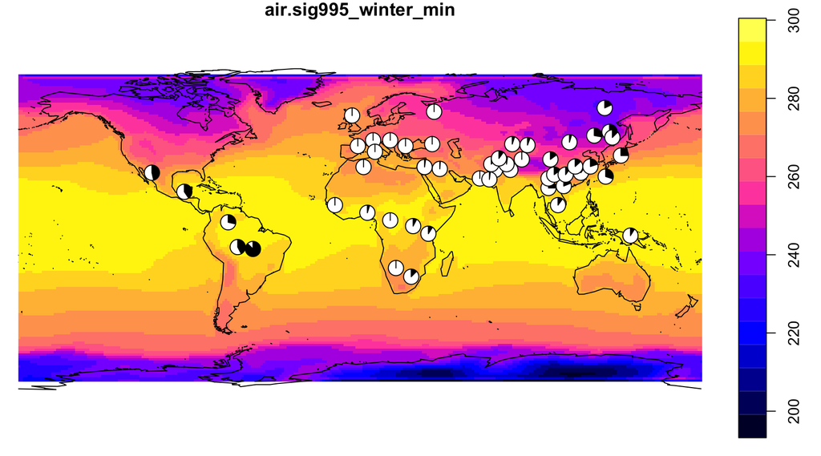

```r
envmap(grid)
addpie(freq_table)
```

## Accessing User Provided Genetic Data

In addition to accessing the genetic data provided in the RGGV databases, the user can map their own genetic data. To do this will require providing the following three files:

1. A tabix indexed and bgzip compressed VCF file of genotype data,
2. An XML file naming the population or populations to which each sample listed in the VCF file belongs (indiv_label file [example](http://genome-data.cri.uchicago.edu/ahga/allpops_auto_maf0.005geno0.1.indiv_label.xml)),
3. An XML file giving the geographical coordinates of each population listed in the indiv_label XML file (pop_geo file [example](http://genome-data.cri.uchicago.edu/ahga/allpops_auto_maf0.005geno0.1.pop_geo.xml)).

In the example indiv_label XML file, each sample has two Population tags with two different level attributes. For the HGDP samples in this example, there is a Population tag for each sample’s population name (`level=1`) and superpopulation, the name describing the population’s region/continent (`level=2`). In a different situation, the different levels could be used to describe a location from which the individual was sampled and a population to which the individual historically belongs. Any number of population levels can be given and the data can then be analyzed/mapped at each level of granularity.